# Homework 08

**Question 1**  
a)

```r
df <- read.csv("data/margin-geometry-20.csv")

df$score <- 0.8 * df$x1 + 0.6 * df$x2
df$distance <- abs(df$score)
df$margin <- df$y * df$score

df$position <- ifelse(df$margin < 1 - 1e-9, "Inside",
               ifelse(abs(df$margin - 1) < 1e-9,
                      "On", "Beyond"))
df
```

```
   observation    x1    x2  y score distance margin position
1            1  0.68  0.76  1  1.00     1.00   1.00       On
2            2  1.80 -0.15  1  1.35     1.35   1.35   Beyond
3            3  1.38  0.66  1  1.50     1.50   1.50   Beyond
4            4  0.88  1.66  1  1.70     1.70   1.70   Beyond
5            5  0.62  2.34  1  1.90     1.90   1.90   Beyond
6            6  2.78 -0.04  1  2.20     2.20   2.20   Beyond
7            7  1.86  1.52  1  2.40     2.40   2.40   Beyond
8            8  0.50  0.40  1  0.64     0.64   0.64   Inside
9            9  0.10  0.20  1  0.20     0.20   0.20   Inside
10          10 -0.40  0.20  1 -0.20     0.20  -0.20   Inside
11          11 -0.92 -0.44 -1 -1.00     1.00   1.00       On
12          12 -0.50 -1.50 -1 -1.30     1.30   1.30   Beyond
13          13 -1.90 -0.05 -1 -1.55     1.55   1.55   Beyond
14          14 -0.44 -2.33 -1 -1.75     1.75   1.75   Beyond
15          15 -1.98 -0.61 -1 -1.95     1.95   1.95   Beyond
16          16 -2.74  0.07 -1 -2.15     2.15   2.15   Beyond
17          17 -1.90 -1.55 -1 -2.45     2.45   2.45   Beyond
18          18 -0.50 -0.40 -1 -0.64     0.64   0.64   Inside
19          19  0.00 -0.40 -1 -0.24     0.24   0.24   Inside
20          20  0.40 -0.20 -1  0.20     0.20  -0.20   Inside
```

Since $\|(0.8,0.6)\|_2=1$, the distance to the decision boundary is

$$d(x)=|0.8x_1+0.6x_2|.$$

The functional margin is

$$yf(x)=y(0.8x_1+0.6x_2).$$

Observations with $yf(x)<1$ are inside the margin, those with $yf(x)=1$ are on the margin, and those with $yf(x)>1$ are beyond the margin. The results are shown in the table above.  
b)

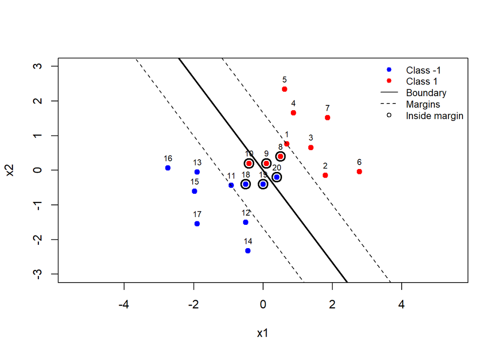

```r
plot(df$x1, df$x2,
     col = ifelse(df$y == 1, "red", "blue"),
     pch = 19,
     xlim = c(-3.2, 3.2), ylim = c(-3, 3),
     asp = 1, xlab = "x1", ylab = "x2")

abline(a = 0, b = -0.8/0.6, lwd = 2)
abline(a = 1/0.6, b = -0.8/0.6, lty = 2)
abline(a = -1/0.6, b = -0.8/0.6, lty = 2)

inside <- df[df$position == "Inside", ]

points(inside$x1, inside$x2,
       pch = 1, cex = 1.8, lwd = 2)

text(df$x1, df$x2, labels = df$observation,
     pos = 3, cex = 0.7)

legend("topright",
       legend = c("Class -1", "Class 1",
                  "Boundary", "Margins", "Inside margin"),
       col = c("blue", "red", "black", "black", "black"),
       pch = c(19, 19, NA, NA, 1),
       lty = c(NA, NA, 1, 2, NA),
       bty = "n", cex = 0.8)
```

The decision boundary is $f(x)=0$, and the two margin lines are $f(x)=\pm1$.

The plot distinguishes the two classes using different colors and highlights observations inside the margin with black circles.

```r
table(factor(df$position,
             levels = c("Inside", "On", "Beyond")))
```

```
Inside     On Beyond
     6      2     12
```

```r
wrong <- df[df$margin < 0, ]

wrong[, c("observation", "margin")]
```

```
   observation margin
10          10   -0.2
20          20   -0.2
```

There are 6 observations inside the margin, 2 on the margin, and 12 beyond the margin.

Observations 10 and 20 are misclassified because their functional margins are negative ($yf(x)=-0.2<0$).

**Question 2**  
a)

```r
df2 <- read.csv("data/margin-geometry-4d.csv")
beta <- c(1, 2, -2, 4)
beta0 <- -1

X <- as.matrix(df2[, c("x1", "x2", "x3", "x4")])

df2$score <- as.vector(X %*% beta + beta0)
df2$projection <- df2$score / sqrt(sum(beta^2))
M <- min(abs(df2$projection))
M
```

```
[1] 1
```

```r
df2[df2$projection %in% c(-M, M),
    c("observation", "projection", "y")]
```

```
   observation projection  y
4            4          1  1
15          15         -1 -1
33          33          1  1
```

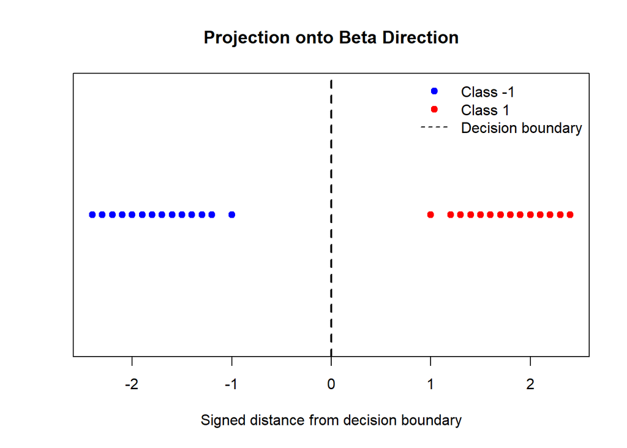

```r
plot(df2$projection, rep(0, nrow(df2)),
     col = ifelse(df2$y == 1, "red", "blue"),
     pch = 19, yaxt = "n", ylab = "",
     xlab = "Signed distance from decision boundary",
     main = "Projection onto Beta Direction")

abline(v = 0, lty = 2, lwd = 2)

legend("topright",
       legend = c("Class -1", "Class 1", "Decision boundary"),
       col = c("blue", "red", "black"),
       pch = c(19, 19, NA),
       lty = c(NA, NA, 2),
       bty = "n")
```

The norm of the coefficient vector is

$$\|\boldsymbol{\beta}\|_2
=\sqrt{1^2+2^2+(-2)^2+4^2}=5.$$

The distance from each observation to the decision boundary is

$$d_i=\frac{|f(x_i)|}{5}.$$

The minimum distance is $M=1$. Observations 4, 15, and 33 are closest to the boundary, with signed distances of $1$, $-1$, and $1$, respectively.

```r
functional_margin <- df2$y * df2$score
min_margin <- min(functional_margin)

beta_new <- beta / min_margin
beta0_new <- beta0 / min_margin

min_margin
```

```
[1] 5
```

```r
beta_new
```

```
[1]  0.2  0.4 -0.4  0.8
```

```r
beta0_new
```

```
[1] -0.2
```

```r
min(df2$y * (as.vector(X %*% beta_new) + beta0_new))
```

```
[1] 1
```

The original minimum functional margin is 5. Dividing all coefficients by 5 gives

$$\boldsymbol{\beta}_{new}
=(0.2,0.4,-0.4,0.8)^T$$

and

$$\beta_{0,new}=-0.2.$$

The minimum functional margin is now 1, and the decision boundary remains unchanged because all coefficients are scaled by the same positive factor.

**Question 3**  
Overall, I think this is a well-designed and functional skill. The AI agent was able to understand the instructions and produce a good analysis report with reasonable results.

One possible improvement would be to provide more detailed instructions for error handling, such as how to deal with missing values or model-fitting failures. Another improvement would be to make the model selection process more explicit, especially when multiple models have very similar cross-validation errors. This could help the AI make more consistent decisions and explain its choices more clearly.

Since some parts of the skill were lost or incorrectly displayed when I copied the content from the PDF, I could not fully verify whether these details were already included in the original instructions. However, the AI agent was still able to follow the available instructions and generate a clear and well-organized report. Therefore, I think the skill works well overall, and these suggestions are mainly intended to improve its clarity and reliability.